# KeplerClassification - 3

```r
library(tidyverse)
library(caret)
library(leaps)
library(MASS)
library(MLmetrics)
library(neuralnet)
data_path <- "data/"
data <- read.csv(paste0(data_path, "data_preprocessed.csv"))
data <- data[,-1]
```

Once read the data, we can split them into training and test set, by the Holdout method. For this aim we are going to exploit the createDataPartition function of caret package, which performs a stratified random split of the data.

```r
set.seed(123)
train_index <- createDataPartition(data$target, p = 0.67, list = FALSE)

train_set <- data[train_index, ]
test_set <- data[-train_index, ]
```

Let’s start with a basic logistic regression model, where we are going to consider all the features available in the data.

```r
mod_logistic_basic <- glm(target ~ . , data = train_set, family = "binomial")
summary(mod_logistic_basic)
```

```
##
## Call:
## glm(formula = target ~ ., family = "binomial", data = train_set)
##
## Deviance Residuals:
##     Min       1Q   Median       3Q      Max
## -1.9434  -0.2291  -0.0333   0.7800   3.7669
##
## Coefficients:
##                 Estimate Std. Error z value Pr(>|z|)
## (Intercept)    1.671e+01  3.795e+00   4.403 1.07e-05 ***
## koi_score      4.752e+00  4.134e-01  11.494  < 2e-16 ***
## koi_fpflag_nt  1.163e+00  4.419e-01   2.633 0.008464 **
## koi_fpflag_ss  1.086e+00  4.540e-01   2.391 0.016787 *
## koi_fpflag_co -1.639e+00  7.853e-01  -2.087 0.036928 *
## koi_fpflag_ec -1.444e+00  1.072e+00  -1.347 0.177944
## koi_period    -5.770e-03  1.142e-03  -5.052 4.37e-07 ***
## koi_time0bk    2.604e-03  1.097e-03   2.373 0.017657 *
## koi_impact    -3.333e-01  1.255e-01  -2.656 0.007908 **
## koi_duration   2.626e-02  1.019e-02   2.577 0.009979 **
## koi_depth     -7.233e-05  1.935e-05  -3.739 0.000185 ***
## koi_prad      -4.059e-02  1.164e-02  -3.487 0.000488 ***
## koi_teq       -5.740e-04  1.860e-04  -3.086 0.002030 **
## koi_insol     -5.419e-05  4.475e-05  -1.211 0.225936
## koi_model_snr  1.448e-03  2.453e-04   5.902 3.60e-09 ***
## koi_steff     -3.594e-04  7.764e-05  -4.629 3.68e-06 ***
## koi_slogg     -2.010e+00  5.501e-01  -3.655 0.000258 ***
## koi_srad      -7.965e-01  2.400e-01  -3.319 0.000903 ***
## ra            -3.172e-02  8.601e-03  -3.687 0.000227 ***
## dec            3.580e-02  1.137e-02   3.149 0.001636 **
## koi_kepmag    -8.349e-02  3.978e-02  -2.099 0.035816 *
## ---
## Signif. codes:  0 '***' 0.001 '**' 0.01 '*' 0.05 '.' 0.1 ' ' 1
##
## (Dispersion parameter for binomial family taken to be 1)
##
##     Null deviance: 6431.8  on 5355  degrees of freedom
## Residual deviance: 3530.0  on 5335  degrees of freedom
## AIC: 3572
##
## Number of Fisher Scoring iterations: 12
```

Let’s consider now the stepwise approach in order to set the best model based on the AIC criterion. In fact, the stepwise selection takes, in this case, the model with all the features built above as input and, considering different sets of features (descresing for each step the number of them), will perform several regressions, calculating the AIC criterion for each of them. The model with the lowest AIC will be considered as the best one for this specific approach.

```r
step.model <- stepAIC(mod_logistic_basic, direction = "backward", trace = FALSE)
```

[output not shown]

[output cut: 24 more lines]

[output not shown]

```r
summary(step.model)
```

```
##
## Call:
## glm(formula = target ~ koi_score + koi_fpflag_nt + koi_fpflag_ss +
##     koi_fpflag_co + koi_fpflag_ec + koi_period + koi_time0bk +
##     koi_impact + koi_duration + koi_depth + koi_prad + koi_teq +
##     koi_model_snr + koi_steff + koi_slogg + koi_srad + ra + dec +
##     koi_kepmag, family = "binomial", data = train_set)
##
## Deviance Residuals:
##     Min       1Q   Median       3Q      Max
## -1.9575  -0.2285  -0.0345   0.7746   3.7704
##
## Coefficients:
##                 Estimate Std. Error z value Pr(>|z|)
## (Intercept)    1.711e+01  3.783e+00   4.523 6.10e-06 ***
## koi_score      4.719e+00  4.120e-01  11.453  < 2e-16 ***
## koi_fpflag_nt  1.145e+00  4.414e-01   2.594 0.009488 **
## koi_fpflag_ss  1.034e+00  4.520e-01   2.288 0.022126 *
## koi_fpflag_co -1.645e+00  7.838e-01  -2.099 0.035840 *
## koi_fpflag_ec -1.455e+00  1.069e+00  -1.361 0.173667
## koi_period    -6.198e-03  1.097e-03  -5.651 1.59e-08 ***
## koi_time0bk    2.617e-03  1.100e-03   2.378 0.017389 *
## koi_impact    -3.376e-01  1.255e-01  -2.691 0.007118 **
## koi_duration   2.564e-02  1.020e-02   2.515 0.011909 *
## koi_depth     -6.983e-05  1.948e-05  -3.584 0.000338 ***
## koi_prad      -4.075e-02  1.161e-02  -3.509 0.000449 ***
## koi_teq       -7.329e-04  1.353e-04  -5.418 6.02e-08 ***
## koi_model_snr  1.417e-03  2.503e-04   5.663 1.48e-08 ***
## koi_steff     -3.473e-04  7.710e-05  -4.505 6.64e-06 ***
## koi_slogg     -2.076e+00  5.481e-01  -3.787 0.000152 ***
## koi_srad      -8.202e-01  2.395e-01  -3.425 0.000614 ***
## ra            -3.172e-02  8.598e-03  -3.690 0.000225 ***
## dec            3.630e-02  1.136e-02   3.196 0.001392 **
## koi_kepmag    -8.429e-02  3.974e-02  -2.121 0.033919 *
## ---
## Signif. codes:  0 '***' 0.001 '**' 0.01 '*' 0.05 '.' 0.1 ' ' 1
##
## (Dispersion parameter for binomial family taken to be 1)
##
##     Null deviance: 6431.8  on 5355  degrees of freedom
## Residual deviance: 3531.5  on 5336  degrees of freedom
## AIC: 3571.5
##
## Number of Fisher Scoring iterations: 10
```

So, we can use the results of the logistic regression performed by the stepwise approach as the baseline for the following models we will use.

We first need to compute the prediction:

```r
prediction_logistic <- predict(step.model, type="response", test_set)
prediction_logistic <- ifelse(prediction_logistic > 0.5, 1, 0)
```

Hence, we are going to assess the logistic regression above through several evaluation measurements: accuracy precision recall F1 measure AUC

```r
precision_logistic <- Precision(test_set$target, prediction_logistic)
recall_logistic <-  Recall(test_set$target, prediction_logistic)
F1measure_logistic <- (2 * precision_logistic * recall_logistic) / (precision_logistic + recall_logistic)
accuracy_logistic <- Accuracy(test_set$target, prediction_logistic)
auc_logistic <- AUC(test_set$target, prediction_logistic)
print('Precision_logistic: '); print(precision_logistic)
```

```
## [1] "Precision_logistic: "
```

```
## [1] 0.9386174
```

```r
print('recall_logistic: '); print(recall_logistic)
```

```
## [1] "recall_logistic: "
```

```
## [1] 0.8289474
```

```r
print('F1_measure_logistic: '); print(F1measure_logistic)
```

```
## [1] "F1_measure_logistic: "
```

```
## [1] 0.8803801
```

```r
print('accuracy_logistic: '); print(accuracy_logistic)
```

```
## [1] "accuracy_logistic: "
```

```
## [1] 0.8377559
```

```r
print('auc_logistic: '); print(auc_logistic)
```

```
## [1] "auc_logistic: "
```

```
## [1] 0.8000379
```

The prediction performed by the model shows good results in term of all the evaluation measures computed. However, this result is biased by the unbalanced distribution of the target variable in the data.

Thus, we can set the results above as the baseline for the following models and trying to carry out some improvement.

Since our data seem to be biased by the presence of unbalanced classes, we will use the function ovun.sample belonging to the package ROSE to perform an oversampling (random generation of records from the minority class):

```r
library(ROSE)
set.seed(123)
data_over <- ovun.sample(target ~ ., data = data, method = "over")$data
table(data_over$target)
```

```
##
##    0    1
## 5713 5655
```

```r
set.seed(123)
train_index <- createDataPartition(data_over$target, p = 0.67, list = FALSE)

train_set <- data_over[train_index, ]
test_set <- data_over[-train_index, ]
print(table(train_set$target))
```

```
##
##    0    1
## 3860 3757
```

```r
print(table(test_set$target))
```

```
##
##    0    1
## 1853 1898
```

Let’s thus re-run the logistic model:

```r
mod_logistic_over <- glm(target ~ . , data = train_set, family = "binomial")
summary(mod_logistic_over)
```

```
##
## Call:
## glm(formula = target ~ ., family = "binomial", data = train_set)
##
## Deviance Residuals:
##     Min       1Q   Median       3Q      Max
## -2.5464  -0.1710   0.0000   0.6676   3.5825
##
## Coefficients:
##                 Estimate Std. Error z value Pr(>|z|)
## (Intercept)    1.333e+01  2.761e+00   4.827 1.39e-06 ***
## koi_score      3.899e+00  2.689e-01  14.499  < 2e-16 ***
## koi_fpflag_nt  5.298e-01  2.847e-01   1.861 0.062714 .
## koi_fpflag_ss  5.317e-01  3.053e-01   1.741 0.081616 .
## koi_fpflag_co -1.229e+00  3.587e-01  -3.426 0.000613 ***
## koi_fpflag_ec -2.152e+00  7.360e-01  -2.924 0.003455 **
## koi_period    -4.484e-03  7.763e-04  -5.776 7.64e-09 ***
## koi_time0bk    2.192e-03  8.832e-04   2.482 0.013069 *
## koi_impact    -4.395e-01  1.050e-01  -4.185 2.85e-05 ***
## koi_duration   1.747e-02  8.332e-03   2.097 0.036029 *
## koi_depth     -7.572e-05  1.432e-05  -5.286 1.25e-07 ***
## koi_prad      -3.985e-02  8.632e-03  -4.617 3.90e-06 ***
## koi_teq       -5.454e-04  1.439e-04  -3.789 0.000151 ***
## koi_insol     -6.303e-05  3.245e-05  -1.942 0.052091 .
## koi_model_snr  1.428e-03  1.968e-04   7.255 4.01e-13 ***
## koi_steff     -3.754e-04  6.580e-05  -5.705 1.16e-08 ***
## koi_slogg     -8.643e-01  3.299e-01  -2.620 0.008796 **
## koi_srad      -2.100e-01  1.070e-01  -1.963 0.049635 *
## ra            -3.233e-02  7.442e-03  -4.344 1.40e-05 ***
## dec            4.011e-02  9.587e-03   4.184 2.86e-05 ***
## koi_kepmag    -1.142e-01  3.366e-02  -3.393 0.000691 ***
## ---
## Signif. codes:  0 '***' 0.001 '**' 0.01 '*' 0.05 '.' 0.1 ' ' 1
##
## (Dispersion parameter for binomial family taken to be 1)
##
##     Null deviance: 10558  on 7616  degrees of freedom
## Residual deviance:  5406  on 7596  degrees of freedom
## AIC: 5448
##
## Number of Fisher Scoring iterations: 11
```

```r
step.model <- stepAIC(mod_logistic_over, direction = "backward", trace = FALSE)
```

[output not shown]

```r
summary(step.model)
```

```
##
## Call:
## glm(formula = target ~ koi_score + koi_fpflag_nt + koi_fpflag_ss +
##     koi_fpflag_co + koi_fpflag_ec + koi_period + koi_time0bk +
##     koi_impact + koi_duration + koi_depth + koi_prad + koi_teq +
##     koi_insol + koi_model_snr + koi_steff + koi_slogg + koi_srad +
##     ra + dec + koi_kepmag, family = "binomial", data = train_set)
##
## Deviance Residuals:
##     Min       1Q   Median       3Q      Max
## -2.5464  -0.1710   0.0000   0.6676   3.5825
##
## Coefficients:
##                 Estimate Std. Error z value Pr(>|z|)
## (Intercept)    1.333e+01  2.761e+00   4.827 1.39e-06 ***
## koi_score      3.899e+00  2.689e-01  14.499  < 2e-16 ***
## koi_fpflag_nt  5.298e-01  2.847e-01   1.861 0.062714 .
## koi_fpflag_ss  5.317e-01  3.053e-01   1.741 0.081616 .
## koi_fpflag_co -1.229e+00  3.587e-01  -3.426 0.000613 ***
## koi_fpflag_ec -2.152e+00  7.360e-01  -2.924 0.003455 **
## koi_period    -4.484e-03  7.763e-04  -5.776 7.64e-09 ***
## koi_time0bk    2.192e-03  8.832e-04   2.482 0.013069 *
## koi_impact    -4.395e-01  1.050e-01  -4.185 2.85e-05 ***
## koi_duration   1.747e-02  8.332e-03   2.097 0.036029 *
## koi_depth     -7.572e-05  1.432e-05  -5.286 1.25e-07 ***
## koi_prad      -3.985e-02  8.632e-03  -4.617 3.90e-06 ***
## koi_teq       -5.454e-04  1.439e-04  -3.789 0.000151 ***
## koi_insol     -6.303e-05  3.245e-05  -1.942 0.052091 .
## koi_model_snr  1.428e-03  1.968e-04   7.255 4.01e-13 ***
## koi_steff     -3.754e-04  6.580e-05  -5.705 1.16e-08 ***
## koi_slogg     -8.643e-01  3.299e-01  -2.620 0.008796 **
## koi_srad      -2.100e-01  1.070e-01  -1.963 0.049635 *
## ra            -3.233e-02  7.442e-03  -4.344 1.40e-05 ***
## dec            4.011e-02  9.587e-03   4.184 2.86e-05 ***
## koi_kepmag    -1.142e-01  3.366e-02  -3.393 0.000691 ***
## ---
## Signif. codes:  0 '***' 0.001 '**' 0.01 '*' 0.05 '.' 0.1 ' ' 1
##
## (Dispersion parameter for binomial family taken to be 1)
##
##     Null deviance: 10558  on 7616  degrees of freedom
## Residual deviance:  5406  on 7596  degrees of freedom
## AIC: 5448
##
## Number of Fisher Scoring iterations: 11
```

The stepwise logistic, applied with oversampling technique, maintains all the features originally belonging to the data.

```r
prediction_logistic <- predict(step.model, type="response", test_set)
prediction_logistic <- ifelse(prediction_logistic > 0.5, 1, 0)
```

```r
precision_logistic <- Precision(test_set$target, prediction_logistic)
recall_logistic <-  Recall(test_set$target, prediction_logistic)
F1measure_logistic <- (2 * precision_logistic * recall_logistic) / (precision_logistic + recall_logistic)
accuracy_logistic <- Accuracy(test_set$target, prediction_logistic)
auc_logistic <- AUC(test_set$target, prediction_logistic)
print('Precision_logistic: '); print(precision_logistic)
```

```
## [1] "Precision_logistic: "
```

```
## [1] 0.9499323
```

```r
print('recall_logistic: '); print(recall_logistic)
```

```
## [1] "recall_logistic: "
```

```
## [1] 0.7576902
```

```r
print('F1_measure_logistic: '); print(F1measure_logistic)
```

```
## [1] "F1_measure_logistic: "
```

```
## [1] 0.8429901
```

```r
print('accuracy_logistic: '); print(accuracy_logistic)
```

```
## [1] "accuracy_logistic: "
```

```
## [1] 0.8605705
```

```r
print('auc_logistic: '); print(auc_logistic)
```

```
## [1] "auc_logistic: "
```

```
## [1] 0.876198
```

Per la func confusion matrix serve fare factor

```r
prediction_logistic <- as.factor(prediction_logistic)
```

```r
test_set$target <- as.factor(test_set$target)
```

```r
confusionMatrix(prediction_logistic,test_set$target,positive='1')
```

```
## Confusion Matrix and Statistics
##
##           Reference
## Prediction    0    1
##          0 1404   74
##          1  449 1824
##
##                Accuracy : 0.8606
##                  95% CI : (0.8491, 0.8715)
##     No Information Rate : 0.506
##     P-Value [Acc > NIR] : < 2.2e-16
##
##                   Kappa : 0.7204
##
##  Mcnemar's Test P-Value : < 2.2e-16
##
##             Sensitivity : 0.9610
##             Specificity : 0.7577
##          Pos Pred Value : 0.8025
##          Neg Pred Value : 0.9499
##              Prevalence : 0.5060
##          Detection Rate : 0.4863
##    Detection Prevalence : 0.6060
##       Balanced Accuracy : 0.8594
##
##        'Positive' Class : 1
##
```

Good, results, despite the simplicity of the algorithm. We will keep the stepwise logistic regression as the baseline for this analysis. If one of the following models will overcome the baseline found by the logistic “by far”, we can consider it as a better model.

Let’s go ahead with one more classification model: Decision Tree.

We will use it as model and features selection method. The first step is to find the optimal hyperparameters.

Decision tree tuning (contains 3 fold cross validation)

```r
set.seed(123)
metric <- "ROC"
data_over$target <- ifelse(data_over$target == 0, 'No','Yes')
train_set$target <- ifelse(train_set$target==0,'No','Yes')
test_set$target <- ifelse(test_set$target==0,'No','Yes')

Ctrl <- trainControl(method = "cv" , number=3, classProbs = TRUE,
summaryFunction = twoClassSummary)
rpartTune <- train(target ~ ., data = train_set, method = "rpart",tuneLength = 5, trControl = Ctrl, metric=metric)
rpartTune
```

```
## CART
##
## 7617 samples
##   20 predictor
##    2 classes: 'No', 'Yes'
##
## No pre-processing
## Resampling: Cross-Validated (3 fold)
## Summary of sample sizes: 5077, 5079, 5078
## Resampling results across tuning parameters:
##
##   cp           ROC        Sens       Spec
##   0.002395528  0.9199557  0.8660568  0.9092342
##   0.002595156  0.9194441  0.8647618  0.9105644
##   0.011711472  0.8970154  0.8520649  0.9017767
##   0.080915624  0.8733312  0.7914589  0.9395829
##   0.677934522  0.7251982  0.8098213  0.6405751
##
## ROC was used to select the optimal model using the largest value.
## The final value used for the model was cp = 0.002395528.
```

Results:

```r
getTrainPerf(rpartTune)
```

```
##    TrainROC TrainSens TrainSpec method
## 1 0.9199557 0.8660568 0.9092342  rpart
```

So, let’s set the CP parameters tuned before:

```r
set.seed(123)
Ctrl_save <- trainControl(method = "cv" , number=3, summaryFunction = twoClassSummary,
classProbs = TRUE, savePredictions = TRUE)

rpartTuneMy <- train(target ~ ., data = train_set, method = "rpart", tuneGrid=data.frame(cp=0.002395528),
trControl = Ctrl_save, metric=metric)
```

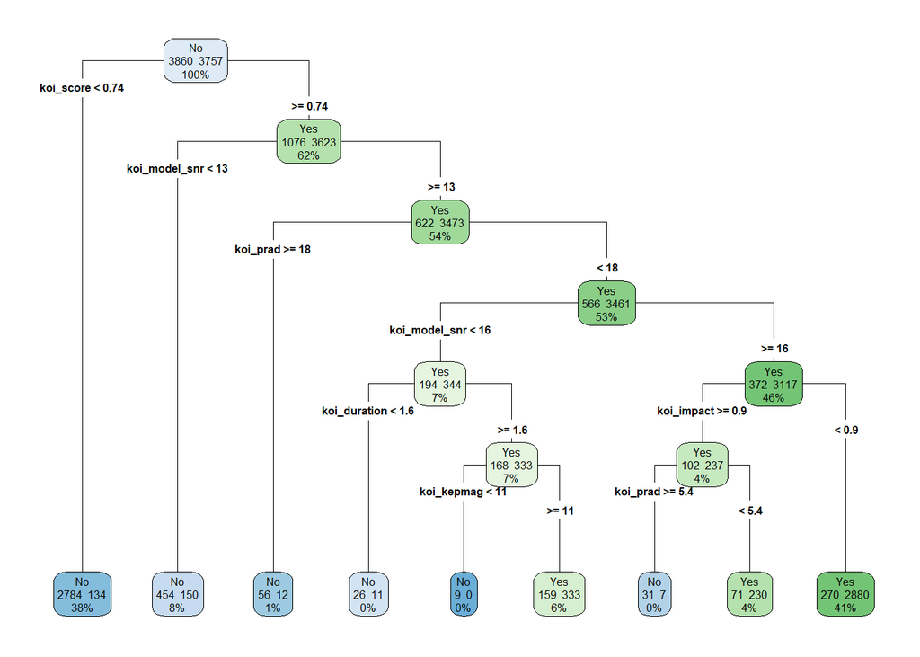

```r
set.seed(123)
library(rpart)
library(rpart.plot)
mytree <- rpart(target ~ ., data = train_set, method = "class", cp = 0.002395528)
rpart.plot(mytree, type = 4, extra = 101, cex = 0.5)
```

Let’s perform Decision Tree prediction

```r
prediction_dt <- predict(mytree, type="prob", test_set)
prediction_dt <- prediction_dt[,2]
prediction_dt <- ifelse(prediction_dt > 0.5, 1, 0)
prediction_dt <- ifelse(prediction_dt == 1, 'Yes', 'No')
```

```r
prediction_dt <- as.factor(prediction_dt)
```

```r
test_set$target <- as.factor(test_set$target)
```

Let’s look now the confusion matrix of the model:

```r
confusionMatrix(prediction_dt,test_set$target,positive='Yes')
```

```
## Confusion Matrix and Statistics
##
##           Reference
## Prediction   No  Yes
##        No  1621  136
##        Yes  232 1762
##
##                Accuracy : 0.9019
##                  95% CI : (0.8919, 0.9112)
##     No Information Rate : 0.506
##     P-Value [Acc > NIR] : < 2.2e-16
##
##                   Kappa : 0.8036
##
##  Mcnemar's Test P-Value : 7.337e-07
##
##             Sensitivity : 0.9283
##             Specificity : 0.8748
##          Pos Pred Value : 0.8837
##          Neg Pred Value : 0.9226
##              Prevalence : 0.5060
##          Detection Rate : 0.4697
##    Detection Prevalence : 0.5316
##       Balanced Accuracy : 0.9016
##
##        'Positive' Class : Yes
##
```

```r
precision_dt <- Precision(test_set$target, prediction_dt)
recall_dt <-  Recall(test_set$target, prediction_dt)
F1measure_dt <- (2 * precision_dt * recall_dt) / (precision_dt + recall_dt)
accuracy_dt <- Accuracy(test_set$target, prediction_dt)
print('Precision_dt: '); print(precision_dt)
```

```
## [1] "Precision_dt: "
```

```
## [1] 0.9225953
```

```r
print('recall_dt: '); print(recall_dt)
```

```
## [1] "recall_dt: "
```

```
## [1] 0.8747976
```

```r
print('F1_measure_dt: '); print(F1measure_dt)
```

```
## [1] "F1_measure_dt: "
```

```
## [1] 0.8980609
```

```r
print('accuracy_dt: '); print(accuracy_dt)
```

```
## [1] "accuracy_dt: "
```

```
## [1] 0.9018928
```

We can now focus on the variables importance. Variable importance might generally be computed based on the corresponding reduction of predictive accuracy when the predictor of interest is removed or some measure of decrease of node impurity.

Analyzing the variables importance:

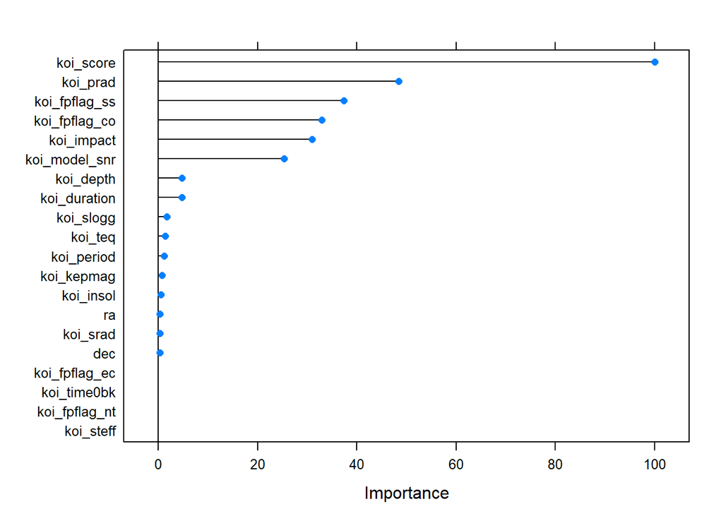

```r
Vimportance <- varImp(rpartTuneMy)
plot(Vimportance)
```

4 out of 20 variables are defined as “not important” by the Decision Tree. In this way, we will carry out a feature selection based on these results:

```r
data_over_selected <- data_over %>%
  dplyr::select(c(target, koi_score, koi_prad, koi_fpflag_ss, koi_fpflag_co, koi_impact, koi_model_snr, koi_depth, koi_duration, koi_slogg, koi_teq, koi_period, koi_kepmag,koi_insol, ra, koi_srad, dec))
```

```r
set.seed(123)
train_index <- createDataPartition(data_over_selected$target, p = 0.67, list = FALSE)

train_set <- data_over_selected[train_index, ]
test_set <- data_over_selected[-train_index, ]
print(table(train_set$target))
```

```
##
##   No  Yes
## 3828 3789
```

```r
print(table(test_set$target))
```

```
##
##   No  Yes
## 1885 1866
```

Now, we can continue the project performing more complex and accurate models, such as random forest. Let’s tune its parameters: (mtry and ntree):

```r
library(randomForest)
customRF <- list(type = "Classification", library = "randomForest", loop = NULL)
customRF$parameters <- data.frame(parameter = c("mtry", "ntree"),
class = rep("numeric", 2),
label = c("mtry", "ntree"))
customRF$grid <- function(x, y, len = NULL, search = "grid") {}
customRF$fit <- function(x, y, wts, param, lev, last, weights, classProbs, ...) {
randomForest(x, y, mtry = param$mtry, ntree=param$ntree, ...)
}
customRF$predict <- function(modelFit, newdata, preProc = NULL, submodels = NULL)
predict(modelFit, newdata)
customRF$prob <- function(modelFit, newdata, preProc = NULL, submodels = NULL)
predict(modelFit, newdata, type = "prob")
customRF$sort <- function(x) x[order(x[,1]),]
customRF$levels <- function(x) x$classes

set.seed(123)
tunegrid <- expand.grid(.mtry=c(4:9), .ntree=c(100,500))


rpartTuneMyRf <- train(target ~ ., data = train_set, method = customRF,
tuneGrid=tunegrid, trControl = Ctrl, metric=metric)
rpartTuneMyRf
```

```
## 7617 samples
##   16 predictor
##    2 classes: 'No', 'Yes'
##
## No pre-processing
## Resampling: Cross-Validated (3 fold)
## Summary of sample sizes: 5078, 5078, 5078
## Resampling results across tuning parameters:
##
##   mtry  ntree  ROC        Sens       Spec
##   4     100    0.9796023  0.8884535  0.9654262
##   4     500    0.9805647  0.8928945  0.9667458
##   5     100    0.9796042  0.8900209  0.9656902
##   5     500    0.9801145  0.8931557  0.9659541
##   6     100    0.9789378  0.8942006  0.9654262
##   6     500    0.9800866  0.8926332  0.9670098
##   7     100    0.9788894  0.8910658  0.9648984
##   7     500    0.9797423  0.8910658  0.9667458
##   8     100    0.9785499  0.8944619  0.9651623
##   8     500    0.9795630  0.8928945  0.9680655
##   9     100    0.9778189  0.8894984  0.9662180
##   9     500    0.9795740  0.8915883  0.9670098
##
## ROC was used to select the optimal model using the largest value.
## The final values used for the model were mtry = 4 and ntree = 500.
```

mtry = 4 and ntree = 500 are judged as the best parameters, so let’s set them and run a Random Forest:

```r
set.seed(123)
tunegrid <- expand.grid(.mtry=4, .ntree=500)
rpartTuneMyRf_ok <- train(target ~ ., data = train_set, method = customRF,
tuneGrid=tunegrid, trControl = Ctrl_save, metric=metric)
rpartTuneMyRf_ok
```

```
## 7617 samples
##   16 predictor
##    2 classes: 'No', 'Yes'
##
## No pre-processing
## Resampling: Cross-Validated (3 fold)
## Summary of sample sizes: 5078, 5078, 5078
## Resampling results:
##
##   ROC        Sens       Spec
##   0.9803562  0.8921108  0.9659541
##
## Tuning parameter 'mtry' was held constant at a value of 4
## Tuning
##  parameter 'ntree' was held constant at a value of 500
```

```r
prediction_RF <- predict(rpartTuneMyRf_ok, type="prob", test_set)
prediction_RF <- prediction_RF[,2]
prediction_RF <- ifelse(prediction_RF > 0.5, 1, 0)
prediction_RF <- ifelse(prediction_RF == 1, 'Yes', 'No')
```

```r
prediction_RF <- as.factor(prediction_RF)
```

```r
test_set$target <- as.factor(test_set$target)
```

Let’s look now the confusion matrix of the model:

```r
confusionMatrix(prediction_RF,test_set$target,positive='Yes')
```

```
## Confusion Matrix and Statistics
##
##           Reference
## Prediction   No  Yes
##        No  1678   48
##        Yes  207 1818
##
##                Accuracy : 0.932
##                  95% CI : (0.9235, 0.9399)
##     No Information Rate : 0.5025
##     P-Value [Acc > NIR] : < 2.2e-16
##
##                   Kappa : 0.8641
##
##  Mcnemar's Test P-Value : < 2.2e-16
##
##             Sensitivity : 0.9743
##             Specificity : 0.8902
##          Pos Pred Value : 0.8978
##          Neg Pred Value : 0.9722
##              Prevalence : 0.4975
##          Detection Rate : 0.4847
##    Detection Prevalence : 0.5399
##       Balanced Accuracy : 0.9322
##
##        'Positive' Class : Yes
##
```

```r
precision_rf <- Precision(test_set$target, prediction_RF)
recall_rf <-  Recall(test_set$target, prediction_RF)
F1measure_rf <- (2 * precision_rf * recall_rf) / (precision_rf + recall_rf)
accuracy_rf <- Accuracy(test_set$target, prediction_RF)
auc_rf <- AUC(test_set$target, prediction_RF)
print('Precision_rf: '); print(precision_rf)
```

```
## [1] "Precision_rf: "
```

```
## [1] 0.97219
```

```r
print('recall_rf: '); print(recall_rf)
```

```
## [1] "recall_rf: "
```

```
## [1] 0.8901857
```

```r
print('F1_measure_rf: '); print(F1measure_rf)
```

```
## [1] "F1_measure_rf: "
```

```
## [1] 0.9293824
```

```r
print('accuracy_rf: '); print(accuracy_rf)
```

```
## [1] "accuracy_rf: "
```

```
## [1] 0.9320181
```

So far, the best results have been achieved by the Random Forest. Let’s try now to build a Neural Network with a single layer.

We will try 3 different tuning parameters methods:

PCA

```r
tunegrid <- expand.grid(size=c(1:5), decay = c(0.0002, 0.0003, 0.00001, 0.0001))
nnetFit_defgridDR1 <- train(train_set[,-1], train_set$target,
method = "nnet",
preProcess = 'pca',
metric=metric,
trControl=Ctrl, tuneGrid=tunegrid,
trace = FALSE,
maxit = 100)
getTrainPerf(nnetFit_defgridDR1)
```

```
##   TrainROC TrainSens TrainSpec method
## 1 0.950892 0.8578892 0.9202956   nnet
```

```r
nnetFit_defgridDR1$bestTune
```

```
##    size decay
## 13    4 1e-05
```

Normalization

```r
tunegrid <- expand.grid(size=c(1:5), decay = c(0.0002, 0.0003, 0.00001, 0.0001))
nnetFit_defgridDR2 <- train(train_set[,-1], train_set$target,
method = "nnet",
preProcess = c('range'),
metric=metric,
trControl=Ctrl, tuneGrid=tunegrid,
trace = FALSE,
maxit = 100)
getTrainPerf(nnetFit_defgridDR2)
```

```
##    TrainROC TrainSens TrainSpec method
## 1 0.9380948 0.8025078 0.9395619   nnet
```

```r
nnetFit_defgridDR2$bestTune
```

```
##    size decay
## 20    5 3e-04
```

Standardization

```r
tunegrid <- expand.grid(size=c(1:5), decay = c(0.0002, 0.0003, 0.00001, 0.0001))
nnetFit_defgridDR3 <- train(train_set[, -1], train_set$target,
method = "nnet",
preProcess = c('center', 'scale'),
metric=metric,
trControl=Ctrl, tuneGrid=tunegrid,
trace = FALSE,
maxit = 100)
getTrainPerf(nnetFit_defgridDR3)
```

```
##    TrainROC TrainSens TrainSpec method
## 1 0.9513467 0.8652038 0.9353391   nnet
```

```r
nnetFit_defgridDR3$bestTune
```

```
##    size decay
## 20    5 3e-04
```

With all the 3 preprocessing methods, we manage to obtain very satisfied results. Let’s keep though the one able to return the best ones, standardization, and run the algorithm:

```r
tunegrid <- expand.grid(size = 1, decay = 0.0003)
nnetFit <- train(train_set[,-1], train_set$target,
method = "nnet",
preProcess = c('center', 'scale'),
metric=metric,
trControl=Ctrl, tuneGrid=tunegrid,
trace = FALSE,
maxit = 100)
getTrainPerf(nnetFit_defgridDR3)
```

```
##    TrainROC TrainSens TrainSpec method
## 1 0.9513467 0.8652038 0.9353391   nnet
```

```r
prediction_NN <- predict(nnetFit, type="prob", test_set)
prediction_NN <- prediction_NN[,2]
prediction_NN <- ifelse(prediction_NN > 0.5, 1, 0)
prediction_NN <- ifelse(prediction_NN == 1, 'Yes', 'No')
```

```r
prediction_NN <- as.factor(prediction_NN)
```

```r
test_set$target <- as.factor(test_set$target)
```

Let’s look now the confusion matrix of the model:

```r
confusionMatrix(prediction_NN,test_set$target,positive='Yes')
```

```
## Confusion Matrix and Statistics
##
##           Reference
## Prediction   No  Yes
##        No  1388   95
##        Yes  497 1771
##
##                Accuracy : 0.8422
##                  95% CI : (0.8301, 0.8537)
##     No Information Rate : 0.5025
##     P-Value [Acc > NIR] : < 2.2e-16
##
##                   Kappa : 0.6847
##
##  Mcnemar's Test P-Value : < 2.2e-16
##
##             Sensitivity : 0.9491
##             Specificity : 0.7363
##          Pos Pred Value : 0.7809
##          Neg Pred Value : 0.9359
##              Prevalence : 0.4975
##          Detection Rate : 0.4721
##    Detection Prevalence : 0.6046
##       Balanced Accuracy : 0.8427
##
##        'Positive' Class : Yes
##
```

```r
precision_nn <- Precision(test_set$target, prediction_NN)
recall_nn <-  Recall(test_set$target, prediction_NN)
F1measure_nn <- (2 * precision_nn * recall_nn) / (precision_nn + recall_nn)
accuracy_nn <- Accuracy(test_set$target, prediction_NN)
print('Precision_nn: '); print(precision_nn)
```

```
## [1] "Precision_nn: "
```

```
## [1] 0.9359407
```

```r
print('recall_nn: '); print(recall_nn)
```

```
## [1] "recall_nn: "
```

```
## [1] 0.7363395
```

```r
print('F1_measure_nn: '); print(F1measure_nn)
```

```
## [1] "F1_measure_nn: "
```

```
## [1] 0.824228
```

```r
print('accuracy_nn: '); print(accuracy_nn)
```

```
## [1] "accuracy_nn: "
```

```
## [1] 0.8421754
```